# R Notebook

Vamos iniciar explorando a função densidade da distribuição GI0 que está implementada a seguir.

```r
# Definindo a densidade da GIO como uma função cujos parâmetros são z, alpha, gamma e Looks
densGI0 <- function(z, alpha, gamma, Looks) {

  return(((Looks^Looks * gamma(Looks-alpha))/ (gamma^alpha * gamma(Looks-1) * gamma(-alpha))) *
    (z^(Looks-1) / (gamma + Looks * z)^(Looks-alpha)))
}
```

A distribuição GI0 entra no contexto das distribuições para intensidade do retorno. As distribuições da intensidade do retorno Z para dados multilook são resultantes do produto de duas variáveis aleatórias independentes Z = XY decorrentes do conhecido Modelo Multiplicativo. As distribuições associadas a X e a Y podem variar conforme a região alvo e produzirem diferentes distribuições para cada dado observado Z. Nesse sentido, a distribuição GI0 representa o sinal de retorno de regiões heterogêneas e é obtida pelo produto de duas variáveis aleatórias independentes, onde X segue uma distribuição Gama inversa de parâmetros alpha e gamma e Y segue uma distribuição Gama com o parâmetro Looks.

Abaixo encontram-se alguns exemplos de resultados gerados a partir da implementação acima, onde foram respeitadas as restrições de que os parâmetros -alpha, gamma e z devem ser maiores que 0 (zero) e de que o parâmetro Looks deve ser maior ou igual a 1 (um).

```r
densGI0(0.07996402, -2, 4, 7)
```

```
[1] 0.001358456
```

```r
densGI0(0.07996402, -2, 4, 8)
```

```
[1] 0.0006118182
```

```r
densGI0(0.07996402, -2, 4, 9)
```

```
[1] 0.0002882424
```

```r
densGI0(0.07996402, -2, 1, 9)
```

```
[1] 1.198833
```

```r
densGI0(0.07996402, -2, 2, 9)
```

```
[1] 0.03097725
```

```r
densGI0(0.07996402, -2, 3, 9)
```

```
[1] 0.002225144
```

```r
densGI0(0.07996402, -3, 3, 9)
```

```
[1] 0.009870448
```

```r
densGI0(0.07996402, -2, 3, 9)
```

```
[1] 0.002225144
```

```r
densGI0(0.07996402, -1, 3, 9)
```

```
[1] 0.0002758938
```

Em análise aos dados gerados percebe-se claramente que a medida que aumentou-se individualmente os valores de cada um dos parâmetros alpha, gamma e Looks deixando os demais fixos, a densidade teve o seu valor diminuído, o que indica que se quisermos uma densidade elevada para uma dada variável aleatória GI0 podemos simplesmente diminuir um dos valores dos parâmetros da função densidade, deixando os demais fixos.

A seguir, temos a geração de variáveis aleatórias GI0 como razão de variáveis aleatórias gama. Como base para alcançar estes resultados utilizou-se o Método Multiplicativo e daí foi possível concluir que poderíamos gerar variáveis aleatórias GI0 da forma escrita a seguir.

```r
# Gerando variáveis aleatórias GI0 como razão de variáveis aleatórias gama
X <- function(alpha, gamma) {
  return(rgamma(shape = -alpha, rate = gamma, n = 100))
}
Y <- function(Looks) {
  return(rgamma(shape = Looks, rate = 1, n = 100))
}
Z <- function(X, Y) {
  return(X/Y)
}
```

De modo análogo ao primeiro código deste RNotebook, foram feitos alguns testes para alguns parâmetros particulares e foram analisadas as respectivas saídas geradas das funções.

```r
# Realizando alguns testes com diferentes entradas de parâmetros.
x = X(-2,4)
y = Y(3)
Z(x,y)
```

```
  [1] 0.005157252 0.194681903 0.073360426 0.187453548 0.078327878 0.070818723 0.337861753
  [8] 0.050613494 0.575757782 0.099876014 0.457333614 0.175019165 0.124770958 0.155049562
 [15] 0.669762009 0.249108358 0.119569024 0.341232484 0.371998021 0.252294036 0.418797123
 [22] 0.070585618 0.044662130 0.047740565 0.277031916 0.024843499 0.102314499 0.324096940
 [29] 0.145264911 0.025778524 0.170411588 0.048810632 0.042092584 0.464040258 0.232086373
 [36] 0.239774652 0.255626161 0.129488233 0.144034509 0.549437755 0.063089338 0.045539616
 [43] 0.046426682 0.102446533 0.429261731 0.045288233 0.116453483 0.439681981 0.094889309
 [50] 0.075473162 0.296262376 0.392930017 0.055102159 0.257873120 0.020386320 0.512556626
 [57] 0.302823166 0.037969844 0.060849045 0.115669223 0.059427738 0.158355093 0.173485131
 [64] 0.335420713 0.011976767 0.589197499 0.117907558 0.214774778 0.244649766 0.406049150
 [71] 1.114126854 0.206606820 0.266215276 0.052746550 0.146004118 0.030857903 0.095500237
 [78] 0.069901779 0.631960940 0.233183103 0.126147907 0.050987704 0.059303192 0.083635533
 [85] 0.013680965 0.111534133 0.279925902 0.086540389 0.179458114 0.391260996 0.046782580
 [92] 0.194360224 0.098651527 0.547866304 0.202046362 0.115360358 0.160735135 0.111723315
 [99] 0.562510986 0.239182762
```

```r
x = X(-10,8)
y = Y(4)
Z(x,y)
```

```
  [1] 0.49189729 0.66603264 0.42406416 0.44445341 1.09965658 0.15151076 0.20046538 0.27088914
  [9] 0.17039985 0.71181853 0.17100329 0.31597254 0.70888656 0.40262289 0.08419798 0.13345362
 [17] 0.37265316 0.30129145 0.13073776 0.22959326 0.77243465 0.14915403 0.44202238 0.50043541
 [25] 0.19247053 0.65303244 0.45710579 0.18566623 0.32519825 0.12844986 0.21810317 0.39638020
 [33] 0.26079811 0.17081199 0.17862831 0.50988177 0.68293617 0.33436416 0.34674212 0.37714035
 [41] 0.19102315 0.33054336 0.20423278 0.54047668 0.54549048 0.30440468 0.25333920 0.16560227
 [49] 0.64027164 1.36392145 1.15916565 0.41686134 0.51775874 0.30008038 0.22233832 0.26970945
 [57] 0.14701496 0.36191049 0.58060532 0.17349442 1.04160287 0.36633605 0.55765310 0.17299645
 [65] 0.81029303 1.53123666 0.35436671 0.62160747 0.39793238 0.17737226 0.23953233 0.23262745
 [73] 0.25625046 0.17891295 0.28499916 0.49772263 0.32074951 0.25519182 0.21595032 0.13317419
 [81] 0.27938343 0.23794496 0.11227181 0.62618475 0.74107339 0.43902826 0.77827223 0.25533532
 [89] 0.16463884 0.48247311 1.82773481 0.59532614 0.28452160 0.18709683 0.24299427 0.15585208
 [97] 0.32806692 0.25308487 0.24679889 0.13648687
```

```r
x = X(-50,25)
y = Y(10)
Z(x,y)
```

```
  [1] 0.38392897 0.20581284 0.43344439 0.23438487 0.27811526 0.19641364 0.18559532 0.21931091
  [9] 0.16595802 0.22544323 0.23007798 0.19596672 0.19149358 0.16501400 0.28887041 0.26292794
 [17] 0.16306708 0.22149588 0.23582041 0.24545122 0.12317354 0.22679502 0.39991523 0.18970748
 [25] 0.42110331 0.18206770 0.27797031 0.37550890 0.20927111 0.10156215 0.12188965 0.24547318
 [33] 0.28115982 0.37625542 0.18524473 0.12277428 0.28336824 0.22687328 0.22394066 0.20723894
 [41] 0.22008178 0.14618520 0.33624128 0.15196962 0.15714427 0.16486919 0.23646906 0.23295811
 [49] 0.14264525 0.21228136 0.14657245 0.30917883 0.33551161 0.22730550 0.15214675 0.19872538
 [57] 0.18905590 0.28484736 0.06920615 0.17973601 0.23788743 0.15296644 0.12286624 0.21705954
 [65] 0.11015846 0.13250730 0.17821679 0.17344055 0.16741820 0.26289570 0.09963500 0.23910489
 [73] 0.41222827 0.08225425 0.19555023 0.16208121 0.15845949 0.26083447 0.16676841 0.17351355
 [81] 0.31654509 0.15769593 0.15116492 0.20894883 0.26901374 0.18515517 0.29636973 0.37718739
 [89] 0.17242344 0.11983563 0.16748407 0.15788408 0.20502013 0.44237308 0.09885581 0.33799013
 [97] 0.12817824 0.14290202 0.23632501 0.51393164
```

Por fim, temos o último código implementado que tem por objetivo explorar o funcionamento dos geradores congruenciais lineares. A seguir encontra-se o código implementado.

```r
# Função em R que recebe os parâmetros necessários que caracterizam um Gerador Congruencial Linear.
# O parâmetro 'size' nesta função nos permite escolher a quantidade de números pseudoaleatórios que queremos gerar.
lcg <- function(M, a, c, seed, size) {
  r = numeric(size)
  r[1] = seed

  for(i in 1:(size-1))
    r[i+1] = (a*r[i] + c) %% M

  return (r/M)
}
```

```r
# Foram realizados alguns testes e gerou-se três sequências de tamanhos variados, cada uma contendo números pseudoaleatórios gerados a partir da implementação anterior do Gerador Congruencial Linear.
seq1 <- lcg(M = 16, a = 5, c = 1, seed = 5, size = 34)
seq2 <- lcg(M = 86436, a = 1093, c = 18257, seed = 7, size = 100)
seq3 <- lcg(M = 394, a = 34, c = -102, seed = 404, size = 50)
```

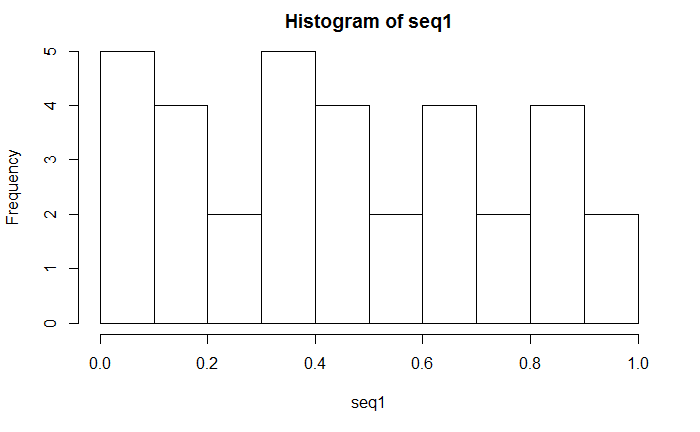

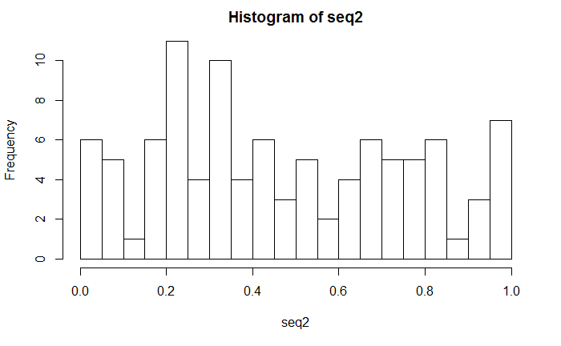

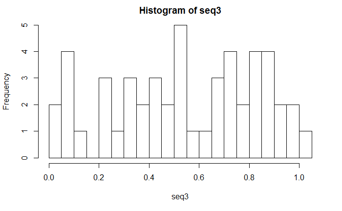

```r
hist(seq1, breaks = 10)
hist(seq2, breaks = 15)

hist(seq3,breaks = 20)
```

As propriedades desejáveis em um gerador de números aleatórios são:

1. Deve ser computacionalmente eficiente: Pode ser preciso milhões de números aleatórios em cada execução, assim, o tempo para processar cada geração deve ser mínimo;
2. Período deve ser muito longo: Um período curto pode fazer com que haja a reciclagem da seqüência de números aleatórios, resultando em uma repetição da seqüência de eventos.
3. Os sucessivos valores devem ser independentes e uniformemente distribuídos: A correlação entre os diversos valores gerados deve ser pequena.

Diante das propriedades acima, temos que em relação a segunda propriedade, a segunda sequência de números pseudoaleatórios gerada, indicada por seq2, é a que possui um maior período e que seria a mais desejável nesse sentido de oferecer uma pequena repetição da sequência de números pseudoaleatórios gerada.